# rdhs package tutorial overview

OJ Watson

2018-02-28

## Overview

The rdhs package helps users interact with the DHS API, as well as facilitate downloading DHS survey datasets and extract individual level data from those surveys. This process is described below and should cover most functionality that will be needed for working with these datasets.

## rdhs client

rdhs was built around an API client that would handle making and parsing API requests to the DHS API. From that, a more nuanced general client tool was created that both made API requests, ensuring that results are cached so they are not looked up again, but also handled the downstream functionality of rdhs. As a result the best way to demonstrate rdhs is to consider the current pipeline through which you might first use rdhs. Each of the following steps are all carried out using the rdhs client, which is an R6 class (similar to R’s built in reference classes and make caching survey and API queries more reproducible):

1. Create the rdhs client
2. Making API requests
3. Using API requests to identify surveys you want to download
4. Cataloging which surveys you can download for your log in credentials
5. Downloading the desired surveys from step 3 from the available surveys from step 4
6. Creating the list of survey questions required for your investigation
7. Using the list from step 6 to create your data frame of survey responses
8. Storing your pipeline from step 1 - 7 to increase reproducibility

Before demonstrating each section, it is worth highlighting why all the above steps are carried out using the highly object-orientated client. The client itself caches the results from each of the above step locally in one way or another. For example, the client when first created is saved in a new local directory that you have specified. Once created it stores the time at which it was last updated, so that every time you use rdhs afterwards, the client will check to see if any of the surveys you have downloaded, or API calls you have made are now out of date. If this happens, the client will let you know, before giving you options over whether to a) completely delete the client’s cache, or b) update any cached surveys or information in bulk now or c) as and when you interact with out of date information. In this way, rdhs hopes to allow studies and analysis of DHS data to both be easier, and reproducible allowing researchers to save their analysis pipeline so that others can replicate it easily.

### 0. Installing the package

```r
# First make sure the package is installed
devtools::install_github("OJWatson/rdhs")

# Load package
library(rdhs)
```

### 1. Create the rdhs client

The client is the bulk of the package’s functionality, and at the moment there are 3 named arguments, *api_key*, *root* and *credentials*. You can apply for an API key from the DHS website that will allow you to leverage more API call returns, and will be stored within the client if declared here. The root argument is the directory path where the client and associated caches will be stored. If left bank, a suitable directory will be created within your user cache directory for your operating system. E.g:

- Mac OS X: ‘~/Library/Caches/’
- Unix: ‘~/.cache/’, $XDG_CACHE_HOME if defined

The credential argument is your login information for the DHS website. This should take the form of a file path that contains 3 lines, something like this:

email="dummy@gmail.com" password=“dummypass” project=“Dummy Project”

These will then be read in and used to create system environment variables so you won’t have to re-enter them within the same session. These will be set to rdhs_USER_PASS/EMAIL/PROJECT, and will be first looked for when trying to create a client. If a credentials argument is provided, this will be used first though.

```r
# Create a client withi our api key and in this root directory
root <- file.path(getwd(),"rdhs_vignette_client_root")

# This if shows that you can make a client if
if(file.exists("credentials")){
  client <- rdhs::dhs_client(api_key = "ICLSPH-527168",credentials = "credentials",root = root)
} else {
  client <- rdhs::dhs_client(api_key = "ICLSPH-527168",root = root)
}

# Have a look at what the client object is
client
```

```
#> <dhs_client>
#>   Public:
#>     available_surveys: function (datasets_api_results = self$dhs_api_request("datasets",
#>     clear_namespace: function (namespace)
#>     dhs_api_request: function (api_endpoint, query = list(), api_key = private$api_key,
#>     download_survey: function (desired_survey, download_option = "rds", reformat = TRUE,
#>     extract: function (questions, add_geo = TRUE)
#>     get_cache_date: function ()
#>     get_root: function ()
#>     initialize: function (api_key = NULL, root = NULL, credentials = NULL)
#>     save_client: function ()
#>     set_cache_date: function (date)
#>     survey_codes: function (desired_survey, codes, essential_codes = NULL)
#>     survey_questions: function (desired_survey, search_terms = NULL, regex = NULL,
#>   Private:
#>     api_endpoints: data indicators countries surveys surveycharacteristics  ...
#>     api_key: ICLSPH-527168
#>     cache_date: 2018-02-28 15:50:17
#>     credentials_path: C:\Users\Oliver\GoogleDrive\AcademicWork\Imperial\git\rd ...
#>     root: C:/Users/Oliver/GoogleDrive/AcademicWork/Imperial/git/rd ...
#>     storr: storr, R6
#>     url: https://api.dhsprogram.com/rest/dhs/
```

The root directory you chose will now also have in it an .rds file that is your dhs client, and a series of subfolders that are used to cache data. In order to use this cached data when you start your next R session you would use the same code as above, but this time it will know you have already created a client and will load it instead.

### 2. Making api requests

The client can then be used to conduct API requests. To find more information about the possible API requests head to their [website](https://api.dhsprogram.com/#/index.html). In brief the API allows for a number of different endpoints to be accessed that constitute one of 12 different databases. These are stored within the client by default, and are the following:

- [data](https://api.dhsprogram.com/#/api-data.cfm)
- [indicators](https://api.dhsprogram.com/#/api-indicators.cfm)
- [countries](https://api.dhsprogram.com/#/api-countries.cfm)
- [surveys](https://api.dhsprogram.com/#/api-surveys.cfm)
- [surveycharacteristics](https://api.dhsprogram.com/#/api-surveycharacteristics.cfm)
- [publications](https://api.dhsprogram.com/#/api-publications.cfm)
- [datasets](https://api.dhsprogram.com/#/api-datasets.cfm)
- [geometry](https://api.dhsprogram.com/#/api-geometry.cfm)
- [tags](https://api.dhsprogram.com/#/api-tags.cfm)
- [dataupdates](https://api.dhsprogram.com/#/api-dataupdates.cfm)
- [uiupdates](https://api.dhsprogram.com/#/api-uiupdates.cfm)
- [info](https://api.dhsprogram.com/#/api-info.cfm)

These endpoints can then be further filtered, with a different set of filters possible for each endpoint. At current, these are not built in so it is possible to make human errors when submitting filter queries. To find info about all the possible filter queries head to the associated webpage from above.

For example we can now query to find out the trends in antimalarial use in Africa, and see if perhaps antimalarial prescription has decreased after RDTs were introduced (assumed 2010). So we can query for that by specifying the “data” endpoint, and using suitable filter queries provided as a list as follows:

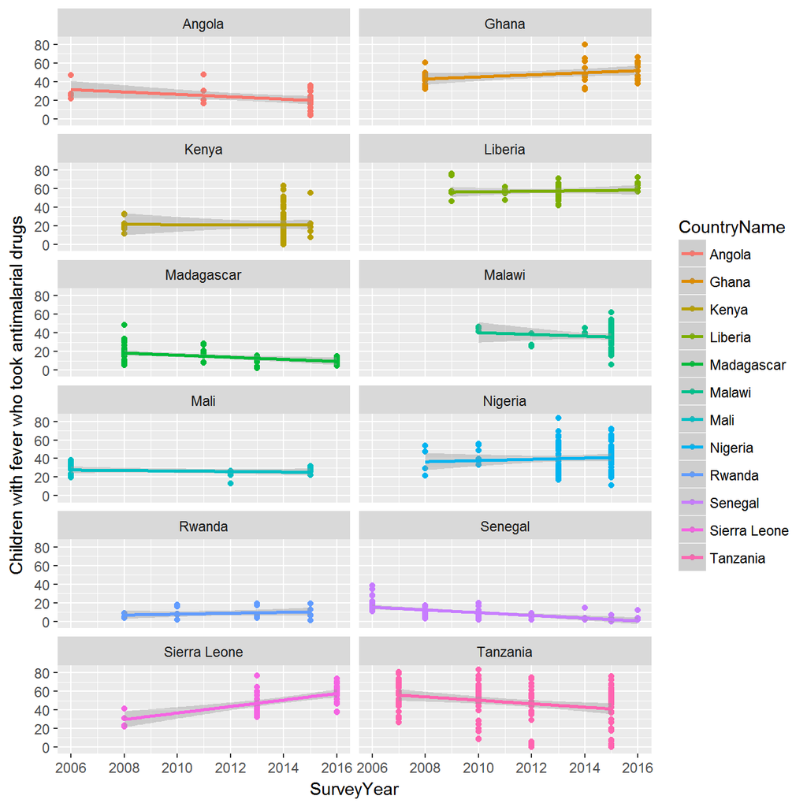

```r
# Make an api request
resp <- client$dhs_api_request(api_endpoint = "data",
                       query = list("indicatorIds"="ML_FEVT_C_AML",
                                    "surveyYearStart"=2006,
                                    "breakdown"="subnational"))


# and let's filter it by some countries
countries  <- c("Angola","Ghana","Kenya","Liberia",
                "Madagascar","Mali","Malawi","Nigeria",
                "Rwanda","Sierra Leone","Senegal","Tanzania")

library(ggplot2)
ggplot(resp[resp$CountryName %in% countries,],
       aes(x=SurveyYear,y=Value,colour=CountryName)) +
  geom_point() +
  geom_smooth(method = "glm") +
  ylab(resp$Indicator[1]) +
  facet_wrap(~CountryName,ncol = 2)
```

If we miss entered a filter query (very possible) rdhs will give you an error that is somewhat nicely presented on the page for you to see way:

```r
# Make an api request
resp <- client$dhs_api_request(api_endpoint = "data",
                       query = list("indicatorIds"="ML_FEVT_C_AMasfafasfL",
                                    "surveyYearStart"=202231231306,
                                    "breakdownAndCry"="subParTyping"))
```

[output not shown]

rdhs by default converts the response to a data.frame and will ensure that all the API results are returned. If you want to return fewer than all the results, or look at the actual API response then these can be controlled using the **num_results** and **just_results** arguments.

Importantly the API request you have made has now been cached by the package. This means that the next time you run this request, the result both returns quicker and you can access your data even if not connected to the internet.

What if the DHS API is updated? Will my cached API calls now be wrong? Potentially. It is unclear from the API how much information changes over time. The [dataupdates](https://api.dhsprogram.com/rest/dhs/dataupdates?f=html) endpoint shows updates to specific surveys. However, when looking at the [datasets](https://api.dhsprogram.com/rest/dhs/datasets?f=html) endpoint we can see that there are many survey files that have been presumably modified after their release. This may be just reuploading, or it could have changed the data and thus subsequent date we may get from API calls. As such, at this moment in time, if the date at which any of the DHS API was last updated as found within the dataupdates endpoint is more recent than the cache_date within our client we will automatically clear our API call cache. The API calls are relatively lightweight, so will not be a major hindrance in the future. This can be seen below:

```r
# Get the current cache date that the client was last created at
client$get_cache_date()
```

```
#> [1] "2018-02-28 15:50:17 GMT"
```

```r
# Now let's set it back in time a year
client$set_cache_date(client$get_cache_date()-(365*24*60*60))
client$get_cache_date()
```

```
#> [1] "2017-02-28 15:50:17 GMT"
```

```r
# And save this client
client$save_client()

# Now let's imagine we were restarting our R session another time and wanted to load our client we were using before
client <- rdhs::dhs_client(api_key = "ICLSPH-527168",
                           root = root,
                           credentials = "credentials")
client$get_cache_date()
```

```
#> [1] "2018-02-28 15:50:25 GMT"
```

### 3. Using api requests to identify surveys you want to download

Working with the API can allow you to get good access to course level data, however you may want access to the raw datasets to compile individual level data. To do this you will need to decide what surveys you want for your survey and then download them. This used to be laborious… and is somewhat nice now.

First we will have a look using the API what surveys record data about children under age five with fever in the two weeks preceding the survey that received any anti-malarial drugs who took Quinine.

```r
# Make an api request
desired_data <- client$dhs_api_request(api_endpoint = "surveys",
                       query = list("indicatorIds"="ML_AMLD_C_QNN"))

str(desired_data,vec.len=2)
```

```
#> Classes 'data.table' and 'data.frame':   93 obs. of  29 variables:
#>  $ ReleaseDate            : chr  "2017-02-15" "2008-02-27" ...
#>  $ SurveyId               : chr  "AF2015DHS" "AO2006MIS" ...
#>  $ MaxAgeWomen            : int  49 49 49 49 49 ...
#>  $ FieldworkStart         : chr  "2015-06-01" "2006-11-01" ...
#>  $ MinAgeMen              : chr  "15" "" ...
#>  $ ImplementingOrg        : chr  "Central Statistics Organization (CSO) and Ministry of Public Health (MoPH)" "COSEP, CONSAÚDE" ...
#>  $ SurveyCharacteristicIds: chr  "92, 39, 6, 1, 79, 31, 14, 57, 8, 34, 17, 22, 20, 24, 21, 13, 36, 59, 3, 11, 26" "8, 41, 57, 36, 68, 63, 61, 26, 79, 89" ...
#>  $ SurveyType             : chr  "DHS" "MIS" ...
#>  $ SurveyYearLabel        : chr  "2015" "2006-07" ...
#>  $ IndicatorData          : int  1 1 1 1 1 ...
#>  $ MinAgeWomen            : int  15 15 15 15 15 ...
#>  $ SurveyYear             : int  2015 2006 2011 2015 2006 ...
#>  $ FieldworkEnd           : chr  "2016-02-01" "2007-04-01" ...
#>  $ DHS_CountryCode        : chr  "AF" "AO" ...
```

[output cut: 16 more lines]

Now we have a data frame for the surveys we want we then go about actually downloading the surveys.

### 4. Cataloguing which surveys you can download for your log in credentials

To do this we again use the client, and pass in our login in credentials, and where we will eventually want to download our surveys too. The client will then log into your DHS account for you and scrape what surveys you have access to. It will then turn these into downloadable urls to be used in the next step. (Takes ~30s)

```r
# client will fetch all the surveys that you can download from the DHS
# website (i.e. the ones they have gien you permission for)
available_surveys <- client$available_surveys()

str(available_surveys,vec.len=2)
```

```
#> 'data.frame':    5536 obs. of  14 variables:
#>  $ FileFormat          : chr  "Stata dataset (.dta)" "Flat ASCII data (.dat)" ...
#>  $ FileSize            : chr  "1126527" "1260002" ...
#>  $ DatasetType         : chr  "Survey Datasets" "Survey Datasets" ...
#>  $ SurveyNum           : chr  "395" "395" ...
#>  $ SurveyId            : chr  "AO2011MIS" "AO2011MIS" ...
#>  $ FileType            : chr  "Births Recode" "Births Recode" ...
#>  $ FileDateLastModified: chr  "May, 08 2017 14:01:32" "May, 08 2017 14:01:49" ...
#>  $ SurveyYearLabel     : chr  "2011" "2011" ...
#>  $ SurveyType          : chr  "MIS" "MIS" ...
#>  $ SurveyYear          : chr  "2011" "2011" ...
#>  $ DHS_CountryCode     : chr  "AO" "AO" ...
#>  $ FileName            : chr  "AOBR62DT.ZIP" "AOBR62FL.ZIP" ...
#>  $ CountryName         : chr  "Angola" "Angola" ...
#>  $ URLS                : chr  "https://dhsprogram.com/customcf/legacy/data/download_dataset.cfm?Filename=AOBR62DT.zip&Tp=1&Ctry_Code=AO&surv_i"| __truncated__ "https://dhsprogram.com/customcf/legacy/data/download_dataset.cfm?Filename=AOBR62FL.zip&Tp=1&Ctry_Code=AO&surv_i"| __truncated__ ...
```

### 5. Downloading the desired surveys from step 3 from the available surveys from step 4

Now that we have the list of surveys, and we now what ones we want to actually download, we simply subset those from step 4 using our dataframe in step 3.

```r
# subset our available data frames
subsetted_surveys <- dplyr::filter(available_surveys, SurveyId %in% desired_data$SurveyId)
```

And we can now download those surveys using our client.

```r
# let's then grab the stata datasets
stata_surveys <- subsetted_surveys[subsetted_surveys$FileFormat=="Stata dataset (.dta)",]

# download datasets
downloads <- client$download_survey(desired_survey=stata_surveys[c(1,25,50,75,100),], reformat = TRUE)
```

```r
x <- lapply(strsplit(list.files(file.path(root,"surveys"),recursive = T,full.names = TRUE), "/"),
            function(z) as.data.frame(t(z)))
x <- dplyr::rbind_all(x)
x$pathString <- apply(x, 1, function(x) paste(trimws(na.omit(tail(x,4))), collapse="/"))
mytree <- data.tree::as.Node(x)
mytree
```

```
#>                        levelName
#> 1  rdhs_vignette_client_root
#> 2   °--surveys
#> 3       ¦--Angola_2006_MIS
#> 4       ¦   °--AOGE52FL.rds
#> 5       ¦--Angola_2011_MIS
#> 6       ¦   ¦--AOBR62DT.rds
#> 7       ¦   °--AOGE61FL.rds
#> 8       ¦--Angola_2015_DHS
#> 9       ¦   °--AOGE71FL.rds
#> 10      ¦--Benin_1996_DHS
#> 11      ¦   °--BJGE33FL.rds
#> 12      ¦--Benin_2001_DHS
#> 13      ¦   °--BJGE42FL.rds
#> 14      ¦--Benin_2012_DHS
```

[output cut: 37 more lines]

Where you can see that a new directory is made for each survey, with any datasets collected from that survey, e.g. birth recode, individual recode, stored within that same directory. The downloads object will now be a list of file paths to where the files were saved to. Depending on the download option this will either be the zip file, the extracted files from the zip, or the rds object created by unzipping the zip file and reading in the approporiate dataset.

A quick look at a demonstration of the reformat:

```r
# let's read one result in and look at that
downloaded_dataset <- readRDS(downloads[[1]][1])
str(downloaded_dataset,list.len = 10)
```

```
#> List of 2
#>  $ Survey                  :'data.frame':    22925 obs. of  316 variables:
#>   ..$ CASEID : chr [1:22925] "        1  1  6" "        1  1  6" "        1  1  6" "        1  3  2" ...
#>   ..$ BIDX   : int [1:22925] 1 2 3 1 2 3 4 5 6 1 ...
#>   ..$ V000   : chr [1:22925] "AO5" "AO5" "AO5" "AO5" ...
#>   ..$ V001   : int [1:22925] 1 1 1 1 1 1 1 1 1 1 ...
#>   ..$ V002   : int [1:22925] 1 1 1 3 3 3 3 3 3 5 ...
#>   ..$ V003   : int [1:22925] 6 6 6 2 2 2 2 2 2 2 ...
#>   ..$ V004   : int [1:22925] 1 1 1 1 1 1 1 1 1 1 ...
#>   ..$ V005   : int [1:22925] 1893232 1893232 1893232 1893232 1893232 1893232 1893232 1893232 1893232 1893232 ...
#>   ..$ V006   : int [1:22925] 3 3 3 3 3 3 3 3 3 3 ...
#>   ..$ V007   : int [1:22925] 2011 2011 2011 2011 2011 2011 2011 2011 2011 2011 ...
#>   .. [list output truncated]
#>  $ Survey_Code_Descriptions:'data.frame':    316 obs. of  2 variables:
#>   ..$ Code       : chr [1:316] "CASEID" "BIDX" "V000" "V001" ...
#>   ..$ Description: chr [1:316] "case identification" "birth column number" "country code and phase" "cluster number" ...
```

```r
# have a look at the survey code descriptions
head(downloaded_dataset$Survey_Code_Descriptions)
```

```
#>     Code              Description
#> 1 CASEID      case identification
#> 2   BIDX      birth column number
#> 3   V000   country code and phase
#> 4   V001           cluster number
#> 5   V002         household number
#> 6   V003 respondent's line number
```

```r
# and let's have a look at how the factor reformat has been helpful
downloaded_dataset$Survey_Code_Descriptions[downloaded_dataset$Survey_Code_Descriptions$Code=="ML101",]
```

```
#>     Code                              Description
#> 96 ML101 type of bednet(s) slept under last night
```

```r
head(downloaded_dataset$Survey$ML101,20)
```

```
#>  [1] "no bednet"            "no bednet"            "no bednet"
#>  [4] "no bednet"            "no bednet"            "no bednet"
#>  [7] "no bednet"            "no bednet"            "no bednet"
#> [10] "only treated bednets" "no bednet"            "only treated bednets"
#> [13] "no bednet"            "no bednet"            "no bednet"
#> [16] "no bednet"            "no bednet"            "only treated bednets"
#> [19] "only treated bednets" "only treated bednets"
```

### 6. Creating the list of survey questions required for your investigation

Now that we have all the surveys downloaded that we want, (which we worked out using the DHS API indicators), we now want to know which survey codes/questions are contained in each survey that we want in our final extracted data frame. To do this we continue using the client, which can iterate though our survey code descriptions.

The reason this is useful, is that some surveys have different codes for the same questions. Therefore it can be difficult to filter by just choosing the codes you want from one survey. Similarly, the questions for the same code may be subtly different, e.g. some report on say fever in the last 2 weeks and some report on fever in the last 4 weeks. So by querying for terms, we can then use the survey specific codes that interest us, and we can use the descriptions to save information about the questions easily.

So let’s now have a look at the surveys we downloaded, and query for survey questions that included anything about fevers, malaria, or tests.

(At the moment the search terms are just combined to produce an OR regex query. )

```r
# extract the questions, and filter by search terms.
questions <- client$survey_questions(stata_surveys[c(1,25,50,75,100),],search_terms = c("fever","malaria","test"))

names(questions)
```

```
#> [1] "Code"        "Description" "Survey"      "SurveyPath"  "CountryCode"
#> [6] "SurveyYear"
```

This resultant data frame can then be used to check which codes you may want to include to extract your raw data.

### 7. Using the list from step 6 to create your data frame of survey responses

We can now quickly view and make a note of the codes that may be of interest to us, and either subset the questions data.frame as needed or directly pass this on to extract the relevant data.

```r
# grab a subset of the questions to save time
subset_quest <- sample(dim(questions)[1],3,replace=FALSE)

# extract the questions, and filter by search terms.
extracted_data <- client$extract(questions[subset_quest,])

# and the structure of the results.
str(extracted_data)
```

```
#> List of 3
#>  $ AO2011:List of 1
#>   ..$ AOBR62DT:'data.frame': 22925 obs. of  7 variables:
#>   .. ..$ S502X   : chr [1:22925] "no" "no" "no" "no" ...
#>   .. ..$ CLUSTER : int [1:22925] 1 1 1 1 1 1 1 1 1 1 ...
#>   .. ..$ ALT_DEM : int [1:22925] 7 7 7 7 7 7 7 7 7 7 ...
#>   .. ..$ LATNUM  : num [1:22925] -12.4 -12.4 -12.4 -12.4 -12.4 ...
#>   .. ..$ LONGNUM : num [1:22925] 13.5 13.5 13.5 13.5 13.5 ...
#>   .. ..$ ADM1NAME: chr [1:22925] "Benguela" "Benguela" "Benguela" "Benguela" ...
#>   .. ..$ DHSREGNA: chr [1:22925] "Mesoendemica Estavel" "Mesoendemica Estavel" "Mesoendemica Estavel" "Mesoendemica Estavel" ...
#>  $ BJ2012:List of 1
#>   ..$ BJIR61DT:'data.frame': 16599 obs. of  7 variables:
#>   .. ..$ H32H_4  : int [1:16599] NA NA NA NA NA NA NA NA NA NA ...
#>   .. ..$ CLUSTER : int [1:16599] 1 1 1 1 1 1 1 1 1 1 ...
#>   .. ..$ ALT_DEM : int [1:16599] 303 303 303 303 303 303 303 303 303 303 ...
#>   .. ..$ LATNUM  : num [1:16599] 11.4 11.4 11.4 11.4 11.4 ...
#>   .. ..$ LONGNUM : num [1:16599] 2.44 2.44 2.44 2.44 2.44 ...
#>   .. ..$ ADM1NAME: chr [1:16599] "Alibori" "Alibori" "Alibori" "Alibori" ...
#>   .. ..$ DHSREGNA: chr [1:16599] "Alibori" "Alibori" "Alibori" "Alibori" ...
#>  $ CG2005:List of 1
#>   ..$ CGCR51DT:'data.frame': 1283 obs. of  7 variables:
#>   .. ..$ ML13D_5 : int [1:1283] NA NA NA NA NA NA NA NA NA NA ...
#>   .. ..$ CLUSTER : int [1:1283] 7 7 7 7 7 7 7 7 7 7 ...
#>   .. ..$ ALT_DEM : logi [1:1283] NA NA NA NA NA NA ...
#>   .. ..$ LATNUM  : logi [1:1283] NA NA NA NA NA NA ...
#>   .. ..$ LONGNUM : logi [1:1283] NA NA NA NA NA NA ...
#>   .. ..$ ADM1NAME: logi [1:1283] NA NA NA NA NA NA ...
#>   .. ..$ DHSREGNA: logi [1:1283] NA NA NA NA NA NA ...
```

### 8. Storing your pipeline from step 1 - 7 to increase reproducibility

The last section is an open ended question still, so any ideas are appreciated. It would be nice to be able to chain the following 7 steps somehow so that the pipeline could then itself be cached so that others could recreate the analysis and so on.

## Summary and further thoughts

Hopefully the above tutorial has shown how the *rdhs* package can facilitate both querying the DHS API and hopefully life some of the difficulty of interacting with the raw datasets. Any suggestions or comments/corrections/errors/ideas please let me know either in the issues or send me an email at "o.watson15@imperial.ac.uk".